# Welcome to Todos Santos!

Thank you for joining us for our workshop on wet-lab techniques in next-generation sequencing. Here is a summary of the topics that we are looking forward to covering.

### Monday November 18

- **12:00-13:00** Lunch (optional upon request with additional cost)
- **13:00-13:30** Introduction to Todos Santos and Group Discussion
- **13:30-14:30** Illumina sequencing chemistry and adapters
- **14:30-15:30** DNA/RNA quality control: methods for estimation of nucleic acid concentration, purity and integrity
- **15:30-15:45** Introduction to 16S rRNA microbiome profiling
- **15:45-17:00** Wet-lab: Illumina 16S rRNA amplicon library construction
- **17:00-18:00** Evening reception
- **18:00-21:00** Dinner on your own

### Tuesday November 19

- **07:00-07:45** Breakfast
- **08:00-08:30** Illumina Library quality control: Quantification
- **08:30-09:00** Illumina Library quality control: Size selection
- **09:00-10:30** Wet Lab: Magnetic bead cleanup and Illumina 16S amplicon library gel electrophoresis
- **10:30-11:00** Barcoding and multiplexing techniques
- **11:00-12:00** Fragmentation
- **12:00-13:00** Lunch
- **13:00-14:00** Introduction to long-read DNA sequencing technologies
- **14:00-16:30** Wet-lab: Construction of Oxford Nanopore libraries and sequencing on a MinIon
- **16:30-18:00** Excursion: Sea turtle release at the beach!
- **18:00-21:00** Dinner on your own

### Wednesday November 20

- **07:00-07:45** Breakfast
- **08:00-08:30** Results from Oxford Nanopore sequencing run
- **08:30-09:00** Making choices in high-throughput sequencing projects
- **09:00-10:00** Introduction to RNA-seq methods
- **10:00-11:00** Experimental design in high-throughput sequencing projects
- **11:00-12:00** Flexible discussion time (UMIs, enrichment techniques, personal projects)
- **12:00-13:00** Lunch (optional upon request with additional cost)

[figure not shown]

[figure not shown]

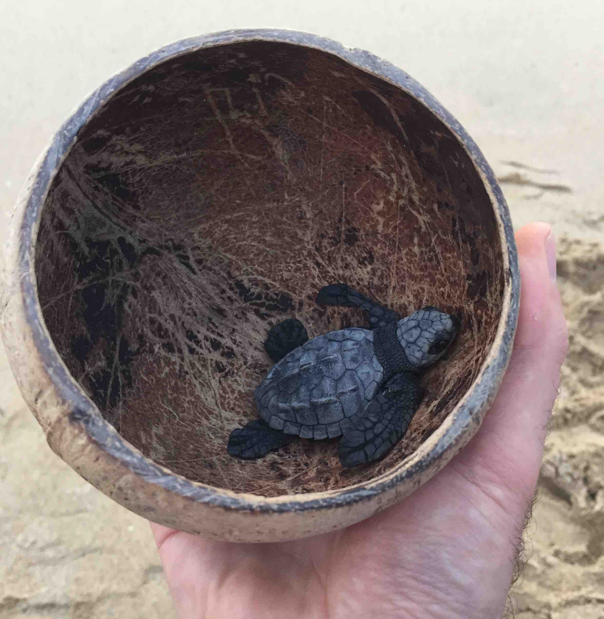

[figure not shown]

Supported by Colorado State University and the National Science Foundation